# Tutorial: How to correct IMERG Late with CDF matching and APHRODITE as reference datasets

Manh-Hung Le (SAIC/ NASA GSFC); Email: manh-hung.le@nasa.gov

July 26th, 2022

# 1 Introduction

Satellite-based precipitation estimates (NRT-SPE) are needed in areas where rain gauges are collected with a significant delay (a few days or months). However, NRT-SPE often contains both random and systematic errors. To reduce systematic error in NRT-SPE, this tutorial uses the Cumulative Distribution Function (CDF). This demonstration uses APHRODITE as a reference dataset and GPM IMERG Late V6 as a target.

## 1.1 Objectives

The following can be learned from this tutorial: * Prepare training and validation datasets for CDF-based adjustment models * Develop CDF transfer function to correct satellite dataset (IMERG Late) based on reference dataset (APHRODITE) * Use the validation set to validate the CDF transfer function.

## 1.2 Data description

The table below describe key variables in this demonstration

```r
#install.packages("stargazer")
knitr::opts_chunk$set(echo = TRUE)
library(stargazer)
require("knitr")
data_description <- data.frame(
  varname = c("aph","rawim","baim"),
  description = c("APHRODITE","raw IMERG Late","bias adjustment IMERG Late"),
  units = c("mm/d","mm/d","mm/d")
)

kable(data_description, caption = "Data description")
```

Data description

| varname | description | units |
| --- | --- | --- |
| aph | APHRODITE | mm/d |
| rawim | raw IMERG Late | mm/d |
| baim | bias adjustment IMERG Late | mm/d |

# 2 Procedure for bias adjustment

## Path setup

This script sets path to the demonstrated files. Please put tutorial1_data and rscripts under the same folder

```r
# set main dir
dir.path = '/media/hung/DATA/rokus_demo' # <path to folder>
setwd(dir.path)
source(file.path(dir.path, 'rscripts/cdf_support_functions.R'))
# unzip data and create path
#unzip(file.path(dir.path,'tutorial1_data.zip'),exdir = dir.path, overwrite = T)
data.path = file.path(dir.path,'tutorial1_data')

#  create path
dir.create(file.path(dir.path,'processed'), showWarnings = F)
processed.path = file.path(dir.path,'processed')
```

## Re-sample IMERG Late

The script resampled the IMERG Late data to match the APHRODITE data (0.1°C to 0.25°C). The flood season (May through October) is the only time we extract daily data. As a final step, we create a raster stack so that each year has multiple raster layers.

```r
library(raster)
library(parallel)

# path to aphrodite
aph.tif.path = file.path(data.path, 'aphro')
aph.tif.files = list.files(aph.tif.path, pattern = '*.tif$', recursive = T, full.names = F)

# path to imerg late
rawim.tif.path = file.path(data.path, 'rawim')
rawim.tif.files = list.files(rawim.tif.path, pattern = '*.tif$', recursive = T, full.names = F)

# ONLY TAKE DATA IN WET SEASON - MAY - OCTOBER #
sel.mon =c('05','06','07','08','09','10')

sel.id = which(substr(aph.tif.files,9,10) %in% sel.mon)
aph.tif.files.sel = aph.tif.files[sel.id]
sel.id = which(substr(rawim.tif.files,14,15) %in% sel.mon)
rawim.tif.files.sel = rawim.tif.files[sel.id]

# read selected raster files
list.aph.tif = lapply(file.path(aph.tif.path, aph.tif.files.sel), raster)
list.rawim.tif = lapply(file.path(rawim.tif.path, rawim.tif.files.sel), raster)

nr = length(list.aph.tif)
aph.tif.sample = list.aph.tif[[1]]

cl = makeCluster(detectCores() - 4)
clusterExport(cl, c('create_raster_from_raster','aph.tif.sample'))

cat('code is runing...','\n')
```

```
## code is runing...
```

```r
list.rawim.tif.res = parLapply(cl, list.rawim.tif,
                            function(x)
                              create_raster_from_raster(oriRas = x, sampleR = aph.tif.sample))

# assign names for each new raw imerg after resample
names(list.rawim.tif.res) = unlist(lapply(list.rawim.tif, names))
names(list.aph.tif) = unlist(lapply(list.aph.tif, names))


# Create raster stack for each year
cat('create raster stack for each year...','\n')
```

```
## create raster stack for each year...
```

```r
uniq.yr = unique(substr(names(list.aph.tif),5,8))
for(ii in 1:length(uniq.yr)){
  cat('-----------', uniq.yr[ii],'\n')
  # for APHRODITE
  id.yr =  which(substr(names(list.aph.tif),5,8) %in% uniq.yr[ii])
  sub.list.aph.tif = list.aph.tif[id.yr]
  stack.aph= stack(sub.list.aph.tif)
  stack.aph.df = as.data.frame(stack.aph, xy = T)
  # for raw IMERG Late
  id.yr =  which(substr(names(list.rawim.tif.res),10,13) %in% uniq.yr[ii])
  sub.list.rawim.tif = list.rawim.tif.res[id.yr]
  stack.rawim= stack(sub.list.rawim.tif)
  stack.rawim.df = as.data.frame(stack.rawim, xy = T)

  op.file = paste0(processed.path,'/','yr_',uniq.yr[ii],'_','aph_rawim.rData')
  save(stack.aph, stack.aph.df ,stack.rawim, stack.rawim.df, file = op.file )
}
```

```
## ----------- 2001
## ----------- 2002
## ----------- 2003
## ----------- 2004
## ----------- 2005
## ----------- 2006
## ----------- 2007
## ----------- 2008
## ----------- 2009
```

## Create calibration and validation dataset.

In this demonstration, we use 2001-2006 as calibration period and 2007-2009 as the validation period

```r
# load and merge datasets for calibration period
cat('============ create calibration dataset=========','\n')
```

```
## ============ create calibration dataset=========
```

```r
cal.yr = seq(2001, 2006, 1)
# first year
ii = 1
 #cat('---', cal.yr[ii],'\n')
load(paste0(processed.path,'/','yr_',cal.yr[ii],'_','aph_rawim.rData'))
stack.aph.cal = stack.aph
stack.aph.cal.df = stack.aph.df
stack.rawim.cal = stack.rawim
stack.rawim.cal.df = stack.rawim.df


for(ii in 2: length(cal.yr)){
  #cat('---', cal.yr[ii],'\n')
  load(paste0(processed.path,'/','yr_',cal.yr[ii],'_','aph_rawim.rData'))
  stack.aph.cal = stack(stack.aph.cal, stack.aph)
  stack.aph.cal.df = cbind.data.frame(stack.aph.cal.df, stack.aph.df[,-c(1,2)])

  stack.rawim.cal = stack(stack.rawim.cal, stack.rawim)
  stack.rawim.cal.df = cbind.data.frame(stack.rawim.cal.df, stack.rawim.df[,-c(1,2)])
}

# save as rData
save(stack.aph.cal, stack.aph.cal.df, stack.rawim.cal, stack.rawim.cal.df,
     file = paste0(processed.path,'/','yr_cal_01_06_aph_rawim.rData') )

# load and merge datasets for validation period
val.yr = seq(2007, 2009, 1)
cat('============ create validation dataset=========','\n')
```

```
## ============ create validation dataset=========
```

```r
# first year
ii = 1
cat('---', val.yr[ii],'\n')
```

```
## --- 2007
```

```r
load(paste0(processed.path,'/','yr_',val.yr[ii],'_','aph_rawim.rData'))
stack.aph.val = stack.aph
stack.aph.val.df = stack.aph.df

stack.rawim.val = stack.rawim
stack.rawim.val.df = stack.rawim.df
for(ii in 2: length(val.yr)){
  cat('---', val.yr[ii],'\n')
  load(paste0(processed.path,'/','yr_',val.yr[ii],'_','aph_rawim.rData'))
  stack.aph.val = stack(stack.aph.val, stack.aph)
  stack.aph.val.df = cbind.data.frame(stack.aph.val.df, stack.aph.df[,-c(1,2)])

  stack.rawim.val = stack(stack.rawim.val, stack.rawim)
  stack.rawim.val.df = cbind.data.frame(stack.rawim.val.df, stack.rawim.df[,-c(1,2)])
}
```

```
## --- 2008
## --- 2009
```

```r
# save as rData
save(stack.aph.val, stack.aph.val.df, stack.rawim.val, stack.rawim.val.df,
     file = paste0(processed.path,'/','yr_val_07_09_aph_rawim.rData'))
```

## Train CDF transfer function

This script develop CDF matching model for each grid.

```r
library(tidyverse)
library(qmap)

# stack raster for bias correction tif
# evaluation metrics
# list of cdf for each grid

####################### CALIBRATION PERIOD
# load calibration dataset
load(paste0(processed.path,'/','yr_cal_01_06_aph_rawim.rData') )

#### create CDF matching model for each grid
ng = nrow(stack.aph.cal.df)
# inital setup
listCDF = list()
stack.baim.cal.df = stack.rawim.cal.df
eval.metrics.ba = data.frame(x = stack.aph.cal.df$x,
                             y = stack.aph.cal.df$y,
                             cc = numeric(ng), # correlation coefficient
                             rb = numeric(ng), # relative bias -
                             rmse = numeric(ng) # root mean square error - mm/d
)
cat('---','grid name','---','latitude of grid centrod',',','longitude of grid centrod','\n')
```

```
## --- grid name --- latitude of grid centrod , longitude of grid centrod
```

```r
for(ii in 1 : ng){
  date = colnames(stack.aph.cal.df)[-c(1,2)] %>% substr(8,15)
  sat.dat = unlist(stack.rawim.cal.df[ii,-c(1,2)])
  obs.dat = unlist(stack.aph.cal.df[ii, -c(1,2)])

  # remove na
  dt = data.frame(date, obs.dat, sat.dat)
  dt.na = na.omit(dt)
  rownames(dt.na) = NULL

  # print results
  cat('---',ii,'---',eval.metrics.ba[ii,1],',',eval.metrics.ba[ii,2],'\n')

  if(dim(dt.na)[1] == 0){
    eval.metrics.ba[ii,-c(1,2)] = NA
    cat('---- no calculation','\n')
    qm.fit = NA
    listCDF[[ii]] = qm.fit
  } else {
    # CFD model built-up
    # only select value greater than 1
    thre.num = 0.1
    id = which(dt.na[,2] >= thre.num & dt.na[,3] >= thre.num)
    dt.na.thr1 = dt.na[id,]
    rownames(dt.na.thr1) = NULL

    # train the model
    qm.fit = fitQmapQUANT(obs = dt.na.thr1[,2], mod = dt.na.thr1[,3], wet.day = T, nboot = 1, type = 'linear')
    # assign correction for original time series
    dt.na$ba.sat = doQmapQUANT(dt.na$sat.dat, qm.fit, type = 'linear')

    ## evaluate bias correction time series
    obs.dat = dt.na$obs.dat; sat.dat = dt.na$ba.sat
    # statistical error
    eval.metrics.ba$cc[ii] = calc_sat_stastics_metrics_single(obs.dat, sat.dat)[1]
    eval.metrics.ba$rb[ii] = calc_sat_stastics_metrics_single(obs.dat, sat.dat)[2]
    eval.metrics.ba$rmse[ii] = calc_sat_stastics_metrics_single(obs.dat, sat.dat)[3]

    # assigned bias correction value to data frame
    dt.final = full_join(dt, dt.na, by = 'date')
    stack.baim.cal.df[ii,-c(1,2)] = dt.final$ba.sat
    listCDF[[ii]] = qm.fit
  }
}
```

```
## --- 1 --- 104.125 , 15.375
## --- 2 --- 104.375 , 15.375
## --- 3 --- 104.625 , 15.375
## --- 4 --- 104.875 , 15.375
## --- 5 --- 105.125 , 15.375
## --- 6 --- 105.375 , 15.375
## --- 7 --- 105.625 , 15.375
## --- 8 --- 105.875 , 15.375
## --- 9 --- 106.125 , 15.375
## --- 10 --- 106.375 , 15.375
## --- 11 --- 106.625 , 15.375
## --- 12 --- 106.875 , 15.375
## --- 13 --- 104.125 , 15.125
## --- 14 --- 104.375 , 15.125
## --- 15 --- 104.625 , 15.125
## --- 16 --- 104.875 , 15.125
## --- 17 --- 105.125 , 15.125
## --- 18 --- 105.375 , 15.125
## --- 19 --- 105.625 , 15.125
## --- 20 --- 105.875 , 15.125
## --- 21 --- 106.125 , 15.125
## --- 22 --- 106.375 , 15.125
## --- 23 --- 106.625 , 15.125
## --- 24 --- 106.875 , 15.125
## --- 25 --- 104.125 , 14.875
## --- 26 --- 104.375 , 14.875
## --- 27 --- 104.625 , 14.875
## --- 28 --- 104.875 , 14.875
## --- 29 --- 105.125 , 14.875
## --- 30 --- 105.375 , 14.875
## --- 31 --- 105.625 , 14.875
## --- 32 --- 105.875 , 14.875
## --- 33 --- 106.125 , 14.875
## --- 34 --- 106.375 , 14.875
## --- 35 --- 106.625 , 14.875
## --- 36 --- 106.875 , 14.875
## --- 37 --- 104.125 , 14.625
## --- 38 --- 104.375 , 14.625
## --- 39 --- 104.625 , 14.625
## --- 40 --- 104.875 , 14.625
```

[output cut: 89 more lines]

```
## --- 130 --- 106.375 , 12.875
## --- 131 --- 106.625 , 12.875
## --- 132 --- 106.875 , 12.875
## --- 133 --- 104.125 , 12.625
## --- 134 --- 104.375 , 12.625
## --- 135 --- 104.625 , 12.625
## --- 136 --- 104.875 , 12.625
## --- 137 --- 105.125 , 12.625
## --- 138 --- 105.375 , 12.625
## --- 139 --- 105.625 , 12.625
## --- 140 --- 105.875 , 12.625
## --- 141 --- 106.125 , 12.625
## --- 142 --- 106.375 , 12.625
## --- 143 --- 106.625 , 12.625
## --- 144 --- 106.875 , 12.625
```

save CDF transfer function for validation data

```r
# save evaluated matrix
eval.metrics.baim.cal.df = eval.metrics.ba
# save QM functions
save(stack.baim.cal.df, eval.metrics.baim.cal.df, listCDF, file = file.path(processed.path,'list.cdf.train.rData'))
```

## Apply CDF transfer function to the validation dataset

After we obtain CDF transfer function for each grid for calibration period. We apply CDF function to new dataset

```r
library(qmap)

####################### VALIDATION PERIOD
load(paste0(processed.path,'/','yr_val_07_09_aph_rawim.rData') )
load(paste0(processed.path,'/','list.cdf.train.rData') )

# only select cdf which have values
id.na = which(is.na(eval.metrics.baim.cal.df$cc))
if(length(id.na) >0){
  eval.metrics.baim.cal.df.adj = eval.metrics.baim.cal.df[-id.na,]
  row.names(eval.metrics.baim.cal.df.adj) = NULL
  listCDF.adj = listCDF[-id.na]
} else {
  eval.metrics.baim.cal.df.adj = eval.metrics.baim.cal.df
  listCDF.adj = listCDF
}


#### create CDF matching model for each grid
ng = nrow(stack.rawim.val.df)

stack.baim.val.df = stack.rawim.val.df
eval.metrics.ba = data.frame(x = stack.rawim.val.df$x,
                             y = stack.rawim.val.df$y,
                             cc = numeric(ng), # correlation coefficient
                             rb = numeric(ng), # relative bias -
                             rmse = numeric(ng) # root mean square error - mm/d

)
cat('---','grid name','---','latitude of grid centrod',',','longitude of grid centrod','\n')
```

```
## --- grid name --- latitude of grid centrod , longitude of grid centrod
```

```r
for(ii in 1 : ng){
  date = colnames(stack.aph.val.df)[-c(1,2)] %>% substr(8,15)
  sat.dat = unlist(stack.rawim.val.df[ii,-c(1,2)])
  obs.dat = unlist(stack.aph.val.df[ii, -c(1,2)])

  # remove na
  dt = data.frame(date, obs.dat, sat.dat)
  dt.na = na.omit(dt)
  rownames(dt.na) = NULL


  # print results
  cat('---',ii,'---',eval.metrics.ba[ii,1],',',eval.metrics.ba[ii,2],'\n')

  if(dim(dt.na)[1] == 0){
    eval.metrics.ba[ii,-c(1,2)] = NA
    cat('---- no calculation','\n')
  } else {
    # coordinates extraction
    xy.target = stack.rawim.val.df[ii,c(1,2)]
    dis.matrix = rep(0, nrow(eval.metrics.baim.cal.df.adj))
    for(kk in 1 : length(dis.matrix)){
      dis.matrix[kk] = c(gcd(xy.target[1], xy.target[2], eval.metrics.baim.cal.df.adj$x[kk], eval.metrics.baim.cal.df.adj$y[kk]))
    }
    dis.matrix = unlist(dis.matrix)
    # finding the closest CDF
    id.close = which(dis.matrix == min(dis.matrix))
    cat('--- id', id.close)
    # assign correction for original time series
    qm.fit = listCDF.adj[[id.close]]
    dt.na$ba.sat = doQmapQUANT(dt.na$sat.dat, qm.fit, type = 'linear')

    ## evaluate bias correction time series
    obs.dat = dt.na$obs.dat; sat.dat = dt.na$ba.sat
    # statistical error
    eval.metrics.ba$cc[ii] = calc_sat_stastics_metrics_single(obs.dat, sat.dat)[1]
    eval.metrics.ba$rb[ii] = calc_sat_stastics_metrics_single(obs.dat, sat.dat)[2]
    eval.metrics.ba$rmse[ii] = calc_sat_stastics_metrics_single(obs.dat, sat.dat)[3]

    cat('---- calculation','\n')
    # assigned bias correction value to data frame
    dt.final = full_join(dt, dt.na, by = 'date')
    stack.baim.val.df[ii,-c(1,2)] = dt.final$ba.sat
  }

# save evaluated matrix for the calibration period
eval.metrics.baim.val.df = eval.metrics.ba
# save as rData
save(stack.baim.val.df, eval.metrics.baim.val.df , file = file.path(processed.path,'metrics.val.rData'))
}
```

```
## --- 1 --- 104.125 , 15.375
## --- id 1---- calculation
## --- 2 --- 104.375 , 15.375
## --- id 2---- calculation
## --- 3 --- 104.625 , 15.375
## --- id 3---- calculation
## --- 4 --- 104.875 , 15.375
## --- id 4---- calculation
## --- 5 --- 105.125 , 15.375
## --- id 5---- calculation
## --- 6 --- 105.375 , 15.375
## --- id 6---- calculation
## --- 7 --- 105.625 , 15.375
## --- id 7---- calculation
## --- 8 --- 105.875 , 15.375
## --- id 8---- calculation
## --- 9 --- 106.125 , 15.375
## --- id 9---- calculation
## --- 10 --- 106.375 , 15.375
## --- id 10---- calculation
## --- 11 --- 106.625 , 15.375
## --- id 11---- calculation
## --- 12 --- 106.875 , 15.375
## --- id 12---- calculation
## --- 13 --- 104.125 , 15.125
## --- id 13---- calculation
## --- 14 --- 104.375 , 15.125
## --- id 14---- calculation
## --- 15 --- 104.625 , 15.125
## --- id 15---- calculation
## --- 16 --- 104.875 , 15.125
## --- id 16---- calculation
## --- 17 --- 105.125 , 15.125
## --- id 17---- calculation
## --- 18 --- 105.375 , 15.125
## --- id 18---- calculation
## --- 19 --- 105.625 , 15.125
## --- id 19---- calculation
## --- 20 --- 105.875 , 15.125
## --- id 20---- calculation
```

[output cut: 233 more lines]

```
## --- id 137---- calculation
## --- 138 --- 105.375 , 12.625
## --- id 138---- calculation
## --- 139 --- 105.625 , 12.625
## --- id 139---- calculation
## --- 140 --- 105.875 , 12.625
## --- id 140---- calculation
## --- 141 --- 106.125 , 12.625
## --- id 141---- calculation
## --- 142 --- 106.375 , 12.625
## --- id 142---- calculation
## --- 143 --- 106.625 , 12.625
## --- id 143---- calculation
## --- 144 --- 106.875 , 12.625
## --- id 144---- calculation
```

## Evaluation of the IMERG Late dataset before and after the bias adjustment procedure.

The evaluation is carried on pixel based. First, we compare average daily between APHRODITE, raw IMERG Late, and bias adjustment IMERG Late

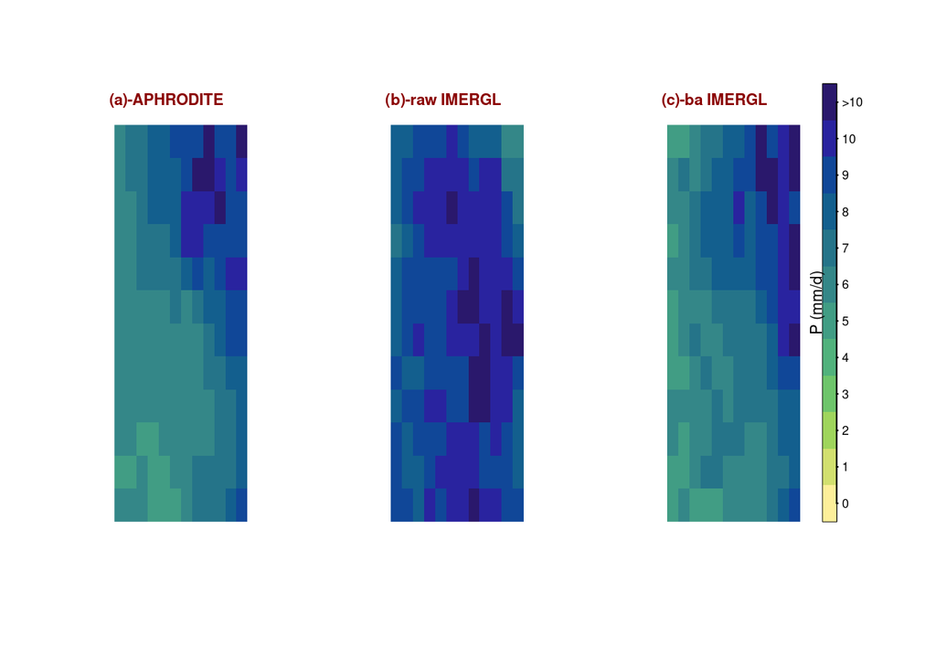

```r
#install.packages('fields')
#install.packages('pals')
library(fields)
library(colorRamps)
library(pals)
# load bias adjustment IMERG data for the calibration period
load(file.path(processed.path,'metrics.val.rData'))
# load raw IMERG data for the calibration period
load(file.path(processed.path,'yr_val_07_09_aph_rawim.rData'))

# create average precipitation raster for APHRODITE
avg.aph.val.df = data.frame(x = stack.aph.val.df$x,
                            y = stack.aph.val.df$y,
                            avg = rowMeans(stack.aph.val.df[, -c(1,2)]))
avg.aph.val.ras = create_raster_from_datXY(datXY = avg.aph.val.df, fieldName = 'avg', sampleR = raster(stack.aph.val, layer = 1))

# create average precipitation raster for raw IMERG Late
avg.rawim.val.df = data.frame(x = stack.rawim.val.df$x,
                             y = stack.rawim.val.df$y,
                             avg = rowMeans(stack.rawim.val.df[, -c(1,2)]))

avg.rawim.val.ras = create_raster_from_datXY(datXY = avg.rawim.val.df, fieldName = 'avg', sampleR = raster(stack.aph.val, layer = 1))

# create average precipitation raster for bias adjustment IMERG Late
avg.baim.val.df = data.frame(x = stack.baim.val.df$x,
                             y = stack.baim.val.df$y,
                             avg = rowMeans(stack.baim.val.df[, -c(1,2)]))

avg.baim.val.ras = create_raster_from_datXY(datXY = avg.baim.val.df, fieldName = 'avg', sampleR = raster(stack.aph.val, layer = 1))

# reclassifiy raster
rec.prep = cbind(seq(-0.5,10.5,1),
                 c(seq(0.5,10.5,1),40), 1:12)
col.precip = rev(ocean.haline(12))
avg.aph.val.ras.rec = reclassify(avg.aph.val.ras, rec.prep)
avg.rawim.val.ras.rec = reclassify(avg.rawim.val.ras, rec.prep)
avg.baim.val.ras.rec = reclassify(avg.baim.val.ras, rec.prep)


par(mfrow = c(1,3), oma = c(1,1,1,4), tck  =-0.01, cex = 0.8)
# panel 1 - APHRODITE-cal 2001-2009
{plot(0,0, col = 'white', xlim = c(104,107), ylim = c(12.5,15.5), xlab = '', ylab = '', axes  =F)
# correct color code
t = rasterToPoints(avg.aph.val.ras.rec )
t.uni = unique(t[,3])
col.precip.adj = col.precip[t.uni[order(t.uni)]]
image(avg.aph.val.ras.rec , col = col.precip.adj, add = T)
mtext('(a)-APHRODITE', cex = 0.7, font = 2, col = 'darkred', adj = 0)
}

{plot(0,0, col = 'white', xlim = c(104,107), ylim = c(12.5,15.5), xlab = '', ylab = '', axes  =F)
# correct color code
t = rasterToPoints(avg.rawim.val.ras.rec )
t.uni = unique(t[,3])
col.precip.adj = col.precip[t.uni[order(t.uni)]]
image(avg.rawim.val.ras.rec , col = col.precip.adj, add = T)
mtext('(b)-raw IMERGL', cex = 0.7, font = 2, col = 'darkred', adj = 0)
}

{plot(0,0, col = 'white', xlim = c(104,107), ylim = c(12.5,15.5), xlab = '', ylab = '', axes  =F)
# correct color code
t = rasterToPoints(avg.baim.val.ras.rec )
t.uni = unique(t[,3])
col.precip.adj = col.precip[t.uni[order(t.uni)]]
image(avg.baim.val.ras.rec , col = col.precip.adj, add = T)
mtext('(c)-ba IMERGL', cex = 0.7, font = 2, col = 'darkred', adj = 0)

image.plot(legend.only = T, zlim  =c(1,12), col = col.precip, horizontal = F,
           legend.width = 0.35, legend.line = -1.5, legend.cex = 0.7,
           legend.lab = "P (mm/d)",
           smallplot = c(0.9,0.95, 0.2, 0.9),
           axis.args = list(at = seq(1,12,1),
                            labels = c(seq(0,10,1), '>10'),
                            cex.axis = 0.7, mgp = c(0, 0.25,0), tck = -0.1)
           )
}
```

Secondly, we compare average precipitation using scatter plots

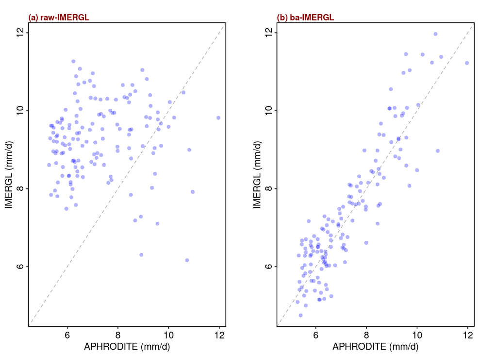

```r
library(tidyverse)

# extract raster to points
# Aphrodite
aph.val.df = rasterToPoints(avg.aph.val.ras) %>% data.frame()
# raw IMERG
rawim.val.df = rasterToPoints(avg.rawim.val.ras) %>% data.frame()
# bias adjustment IMERG
baim.val.df = rasterToPoints(avg.baim.val.ras) %>% data.frame()

# merge reference and raw IMERG
val.rawim.df = left_join(aph.val.df, rawim.val.df, by = c('x','y'))
colnames(val.rawim.df) = c('x','y','obs','sat')

# merge reference and bias adjustment IMERG
val.baim.df = left_join(aph.val.df, baim.val.df, by = c('x','y'))
colnames(val.baim.df) = c('x','y','obs','sat')

yrange = range(c(aph.val.df[,-c(1,2)], rawim.val.df [,-c(1,2)], baim.val.df[,-c(1,2)]))
one.one.line = data.frame(x = c(0,100),
                          y = c(0,100))

par(mfrow = c(1,2), mar = c(2.5,2.5,2,2), mgp = c(1.25,0.25, 0), tck = -0.01, cex = 0.8)
plot(val.rawim.df$obs, val.rawim.df$sat, pch  = 16, col = t_col('blue'),
     cex = 0.9, xlim = yrange, ylim = yrange,
     xlab = 'APHRODITE (mm/d)', ylab = c('IMERGL (mm/d)'))
points(one.one.line$x, one.one.line$y, type = 'l',lwd = 0.5, lty = 2, col = 'grey50')
mtext('(a) raw-IMERGL', cex = 0.7, font = 2, col = 'darkred', adj = 0)


# panel 4
plot(val.baim.df$obs, val.baim.df$sat, pch  = 16, col = t_col('blue'),
     cex = 0.9, xlim = yrange, ylim = yrange,
     xlab = 'APHRODITE (mm/d)', ylab = c('IMERGL (mm/d)'))
points(one.one.line$x, one.one.line$y, type = 'l', lwd = 0.5, lty = 2, col = 'grey50')
mtext('(b) ba-IMERGL ', cex = 0.7, font = 2, col = 'darkred', adj = 0)
```

# 3 Acknowledgment

This demonstration thanks UCAR and NASA to make APHRODITE and GPM IMERG data freely accessible for our demonstration.